# Machine Learning Project

Pilar

Sunday, November 16, 2014

# Synopsis

The goal of this project is *to predict* the manner in wich a group of enthusiasts did the exercise. For it we use data from accelerometers on the belt, forearm, arm and dumbell of 6 participants. They were asked to perform barbell lifts correctly and incorrectly in 5 different ways.

My strategy consists in building 2 models and compare them. This comparison will be centered on the accuracy level. The first model use the *Principal Component Analysis* tool, because some of predictors are highly correlated with each other. The second model use the subset of the training data , that in a previous step I splitted in two parts.

In both cases (models), I use the *random forest* technique, because is one of the accurate learning algorithms. Also I use *cross validation* as a type of resampling.

# Data Processing

## Loading and Reading Data

```r
library(lattice)
library(ggplot2)
library(caret)
library(randomForest)
library(AppliedPredictiveModeling)
setwd("F:/Practical Machine Learning/Project")
if (!file.exists("pml-training.csv")){
    download.file("https://d396qusza40orc.cloudfront.net/predmachlearn/pml-training.csv", destfile="pml-training.csv", method="curl")
    }

if (!file.exists("pml-testing.csv")){
    download.file("https://d396qusza40orc.cloudfront.net/predmachlearn/pml-testing.csv", destfile="pml-testing.csv", method="curl")
    }

training<-read.csv("pml-training.csv", na.strings=c("NA", ""), header=TRUE)
testing<-read.csv("pml-testing.csv", na.strings=c("NA", ""), header=TRUE)
dim(training)
```

```
## [1] 19622   160
```

```r
dim(testing)
```

```
## [1]  20 160
```

As you can see from the above information, the number of variables is 160. We try to reduce them.

## Cleaning Data

I remove all the columns of training and testing which NA values represents more than 90% of the total.

```r
## Removing columns from training
for(data in training) {
  columns_to_delete <- NULL

### find columns threshold
  threshold_columns <- floor(nrow(training)*0.1)

### find columns to delete
  valuecount_columns <- colSums(!is.na(training))
  columns_to_delete <- sort(which(valuecount_columns < threshold_columns), decreasing = TRUE)

 ### delete columns with less than x values
  for(column_id in columns_to_delete) {
    training[column_id] <- NULL
    }
}

dim(training)
```

```
## [1] 19622    60
```

```r
## Removing columns from testing
for(data in testing) {
  columns_to_delete <- NULL

### find columns threshold
  threshold_columns <- floor(nrow(testing)*0.1)

### find columns to delete
  valuecount_columns <- colSums(!is.na(testing))
  columns_to_delete <- sort(which(valuecount_columns < threshold_columns), decreasing = TRUE)

### delete columns with less than x values
  for(column_id in columns_to_delete) {
    testing[column_id] <- NULL
    }
}
dim(testing)
```

```
## [1] 20 60
```

Comparing if the columns of training are the same that the columns of testing, except the last column, that in *testing data set* is *problem_id* and in *training data set* is *classe*.

```r
colnamesTrain<-colnames(training)
colnamesTest<-colnames(testing)
all.equal(colnamesTest[1:length(colnamesTest)-1], colnamesTrain[1:length(colnamesTrain)-1])
```

```
## [1] TRUE
```

I delete the first seven columns related with variables like: *index*, *username*, *times* and *window*.

```r
training<- training[, 8:length(colnames(training))]
dim(training)
```

```
## [1] 19622    53
```

```r
testing<- testing[, 8:length(colnames(testing))]
dim(testing)
```

```
## [1] 20 53
```

Finally we have only 53 variables, 52 of them will be use to build the model and the remaining will be the outcome variable.

# Modeling

Split the *training set* into *training/testing sets*. Then build a model on the *training set* as subset of our oringinal *training set*. After that evaluate on the *test set* as subset of our original *training set*.

## Removing zero covariates

Now we try to identify variables with zero variation. This variables are not useful for building the model and we will proceed to remove them.

```r
nsv<-nearZeroVar(training, saveMetrics=TRUE)
nsvDrop<- nsv[nsv$nzv==TRUE, ]
namesDrop<-rownames(nsvDrop)
newTraining<-training[, !((colnames(training)%in% namesDrop))]
dim(newTraining)
```

```
## [1] 19622    53
```

There isn’t any covariates.

## Data Splitting

I split the *training data set* using random subsampling without replacement.In order to be *reproducible* I set a *specific seed*

```r
set.seed(1235)
inTrain<-createDataPartition(y=newTraining$classe, p=0.75, list=FALSE)
myTraining<-newTraining[inTrain,]
myTesting<-newTraining[-inTrain,]
dim(myTraining)
```

```
## [1] 14718    53
```

```r
dim(myTesting)
```

```
## [1] 4904   53
```

```r
summary(myTraining$classe)
```

```
##    A    B    C    D    E
## 4185 2848 2567 2412 2706
```

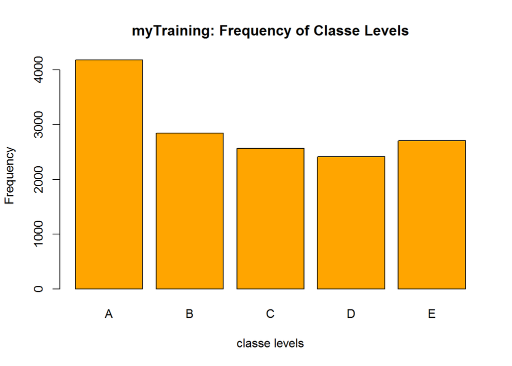

```r
plot(myTraining$classe, col="orange", main="myTraining: Frequency of Classe Levels", xlab="classe levels", ylab="Frequency")
```

The *classe level A* is the most frequently.

## Model 1: PCA, Cross Validation and Random Forest

First at all I calculated the correlation between the variables. Then I applied *Principal Components Analysis* technique to reduce the number of the predictors. After that I build a model using *Rrandom Forest* technique and *cross validation* method of resampling. Finally testing the model.

### Correlated predictors

```r
M <- abs(cor(myTraining[, -53]))
diag(M)<-0
corTab<-which(M>0.8, arr.ind=TRUE)
dim(corTab)
```

```
## [1] 38  2
```

There are some variables highly correlated with each other, that is why I decide to apply *Principal Components Analysis* tool.

### Principal Components Analysis

```r
preProc<-preProcess(myTraining[, -53], method="pca")
trainPC<-predict(preProc, myTraining[, -53])
dim(trainPC)
```

```
## [1] 14718    25
```

```r
testPC<-predict(preProc, myTesting[, -53])
dim(testPC)
```

```
## [1] 4904   25
```

PCA needs 25 components of *myTraining data set* to capture 95 percent of the variance.

### Random Forest and Cross Validation

I will apply the technique of Random Forest modeling to predict the classe. I will use the PCA data set: *trainPC* for training the model, and *testPC* for testing.

```r
fitControl<-trainControl(method = "cv", number = 5)
modelFit<-train(myTraining$classe~., method="rf", trControl = fitControl, prox=TRUE, ntree=100, data=trainPC)
modelFit$finalModel
```

```
##
## Call:
##  randomForest(x = x, y = y, ntree = 100, mtry = param$mtry, proximity = TRUE)
##                Type of random forest: classification
##                      Number of trees: 100
## No. of variables tried at each split: 2
##
##         OOB estimate of  error rate: 2.8%
## Confusion matrix:
##      A    B    C    D    E class.error
## A 4141   12   17   12    3  0.01051374
## B   59 2725   49    3   12  0.04318820
## C    7   41 2490   20    9  0.02999610
## D   11    3   96 2297    5  0.04767828
## E    1   15   21   16 2653  0.01958610
```

```r
## accuracy and expected out-of-sample error
conMat<-confusionMatrix(myTesting$classe, predict(modelFit, testPC))
accur<-round(conMat$overall[1], 2)
accur
```

```
## Accuracy
##     0.97
```

```r
expErrorOS<-round((1-accur), 4)
expErrorOS
```

```
## Accuracy
##     0.03
```

The *accuracy* of this model is **0.97**. The *accuracy* measures the *correct* predictions against the number of total predictions. Meanwhile *expected out-of-sample error* measures the number of *incorrect* predictions against the number of total predictions. That is why, *expected out-of-sample error* is **0.03**.

## Model 2: Random Forest and Testing

These model is building with all the variables in *myTraining* data set. I will apply the technique of Random Forest modeling to predict the classe. I will use *myTraining data set* for training the model, and *myTesting* for testing.

```r
fitControl<-trainControl(method = "cv", number = 5)
modelFit1<-train(myTraining$classe~., method="rf", trControl = fitControl, prox=TRUE, ntree=50, data=myTraining)
modelFit1$finalModel
```

```
##
## Call:
##  randomForest(x = x, y = y, ntree = 50, mtry = param$mtry, proximity = TRUE)
##                Type of random forest: classification
##                      Number of trees: 50
## No. of variables tried at each split: 27
##
##         OOB estimate of  error rate: 0.87%
## Confusion matrix:
##      A    B    C    D    E class.error
## A 4174    6    2    3    0 0.002628435
## B   24 2813   10    0    1 0.012289326
## C    0   22 2536    9    0 0.012076354
## D    0    1   30 2380    1 0.013266998
## E    0    3    7    9 2687 0.007021434
```

```r
## accuracy and expected out-of-sample error
conMat1<-confusionMatrix(myTesting$classe, predict(modelFit1, myTesting))
accur1<-round(conMat1$overall[1], 2)
accur1
```

```
## Accuracy
##     0.99
```

```r
expErrorOS1<-round(1-accur1, 4)  ## expected out-of-sample error
expErrorOS1
```

```
## Accuracy
##     0.01
```

The *accuracy* of this model is **0.99**. Meanwhile *expected out-of-sample error* is **0.01**, very low. Then I expect that the number of *incorrect* predictions against the total number predictions will be very few.

## Compare Models

Now I compare both Models (modelFit and modelFit1) using the *accuracy level*

```r
difAccur<-accur1-accur
difAccur
```

```
## Accuracy
##     0.02
```

```r
difAccurPerc<-round(difAccur*100, 2)
```

The level of accuracy in *modelFit1* is a little greater, that is why I decided to choose *modelFit1*

# Prediction

I use *ModelFit1* and *testing data set* to predict the classe. With a very low *out-of-sample error* and with n=20 classes in our *testing data set*, we expect *very few or none incorrect* classe predictions.

```r
predictTest<- predict(modelFit1, testing[, -53])
predictTest
```

```
##  [1] B A B A A E D B A A B C B A E E A B B B
## Levels: A B C D E
```

# References:

International Journal for Infonomics (IJI), Volume 3, Issue 3, September 2010

Velloso, E.; Bulling, A.; Gellersen, H.; Ugulino, W.; Fuks, H. Qualitative Activity Recognition of Weight Lifting Exercises. Proceedings of 4th International Conference in Cooperation with SIGCHI (Augmented Human ’13) . Stuttgart, Germany: ACM SIGCHI, 2013.